# Covid_project

```python
import numpy as np
import pandas as pd
import matplotlib.pyplot as plt
import seaborn as sns

from keras.preprocessing.image import ImageDataGenerator
from keras.models import Sequential
from keras.layers import Dense, Conv2D, Flatten, MaxPooling2D, Dropout
from keras.utils import to_categorical

from sklearn.model_selection import train_test_split

from matplotlib.widgets import Cursor
from ipywidgets import interact, interactive, fixed, interact_manual
import ipywidgets as widgets
import cv2

from sklearn.preprocessing import LabelEncoder
from keras.utils import to_categorical
from keras.models import Sequential
from keras.layers import Conv2D, MaxPooling2D, Flatten, Dense, Dropout
from keras.optimizers import Adam
from keras.callbacks import EarlyStopping
```

```python
from google.colab import drive
drive.mount('/content/drive/')
```

```python
# Load the images and labels
images = np.load("/content/drive/My Drive/Covid_Cnn_project/CovidImages.npy")
labels = pd.read_csv("/content/drive/My Drive/Covid_Cnn_project/CovidLabels.csv")
```

```python
labels
```

|  | Label |
| --- | --- |
| 0 | Viral Pneumonia |
| 1 | Viral Pneumonia |
| 2 | Viral Pneumonia |
| 3 | Viral Pneumonia |
| 4 | Viral Pneumonia |
| ... | ... |
| 246 | Normal |
| 247 | Normal |
| 248 | Normal |
| 249 | Normal |
| 250 | Normal |

251 rows × 1 columns

```python
labels.head()
```

|  | Label |
| --- | --- |
| 0 | Viral Pneumonia |
| 1 | Viral Pneumonia |
| 2 | Viral Pneumonia |
| 3 | Viral Pneumonia |
| 4 | Viral Pneumonia |

```python
labels.tail()
```

|  | Label |
| --- | --- |
| 246 | Normal |
| 247 | Normal |
| 248 | Normal |
| 249 | Normal |
| 250 | Normal |

```python
labels.info()
```

```
<class 'pandas.core.frame.DataFrame'>
RangeIndex: 251 entries, 0 to 250
Data columns (total 1 columns):
 #   Column  Non-Null Count  Dtype
---  ------  --------------  -----
 0   Label   251 non-null    object
dtypes: object(1)
memory usage: 2.1+ KB
```

```python
labels.describe()
```

|  | Label |
| --- | --- |
| count | 251 |
| unique | 3 |
| top | Covid |
| freq | 111 |

```python
labels['Label'].value_counts()
```

```
Covid              111
Viral Pneumonia     70
Normal              70
Name: Label, dtype: int64
```

```python
labels.columns
```

```
Index(['Label'], dtype='object')
```

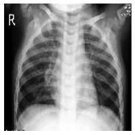

```python
# Plot the first image in the dataset
plt.imshow(images[0], cmap='gray')
plt.axis('off')
plt.show()
```

[figure not shown]

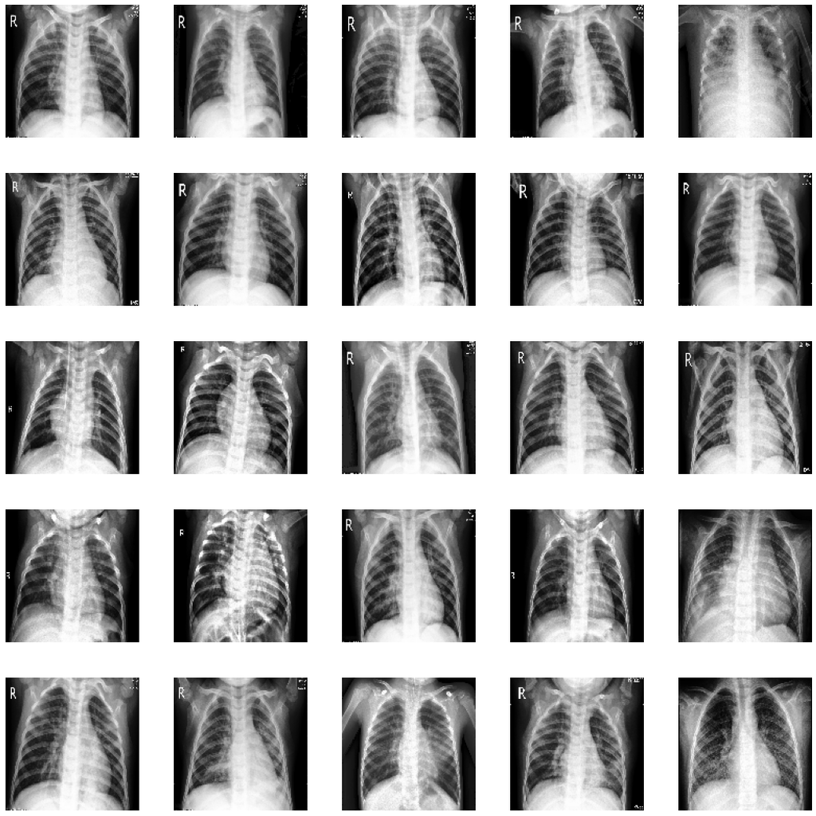

```python
from IPython.display import display
from IPython.display import HTML
from PIL import Image

# Create a function to display images in a grid
def display_images(images, cols=5, rows=5, figsize=(15, 15)):
    figure, axes = plt.subplots(rows, cols, figsize=figsize)
    figure.tight_layout()
    for ax, image in zip(axes.flat, images):
        ax.imshow(image)
        ax.axis('off')

# Make the grid of images scrollable
def make_scrollable(images):
    display(HTML(f"<style>.container {{ width:100%; height:450px; overflow-x: scroll; white-space: nowrap; }}</style>"))
    display(HTML(f"<div class='container'>" + " ".join([f"<img src='{i}' style='display:inline-block;margin:10px;width:100px;height:100px;'>" for i in images]) + "</div>"))

# Call the display_images function
display_images(images)

# Call the make_scrollable function
make_scrollable(images)
```

[figure not shown]

```python
# Plot the images from each class and print their corresponding labels
fig, axs = plt.subplots(1, 3, figsize=(15, 5))

for label, ax in zip(labels['Label'].unique(), axs):
    image = images[labels['Label'] == label][0]
    ax.imshow(image, cmap='gray')
    ax.set_title(label)
    ax.axis('off')

# Count plot for each category
sns.countplot(x='Label', data=labels)
plt.gcf().set_size_inches(15, 12)
plt.show()
```

[figure not shown]

```python
# Show the distribution of image sizes
sizes = [image.shape for image in images]
sns.displot(sizes, height=5, aspect=2)
plt.title('Distribution of Image Sizes')
plt.xlabel('Image Width x Height')
plt.ylabel('Count')
plt.show()
```

[output not shown]

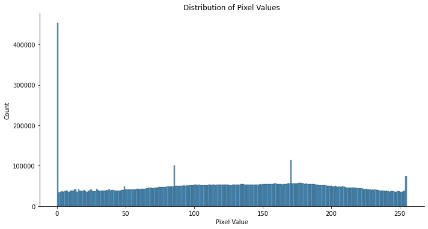

```python
# Show the distribution of pixel values
pixel_values = images.flatten()
sns.displot(pixel_values, height=5, aspect=2, kde=False)
plt.title('Distribution of Pixel Values')
plt.xlabel('Pixel Value')
plt.ylabel('Count')
plt.show()
```

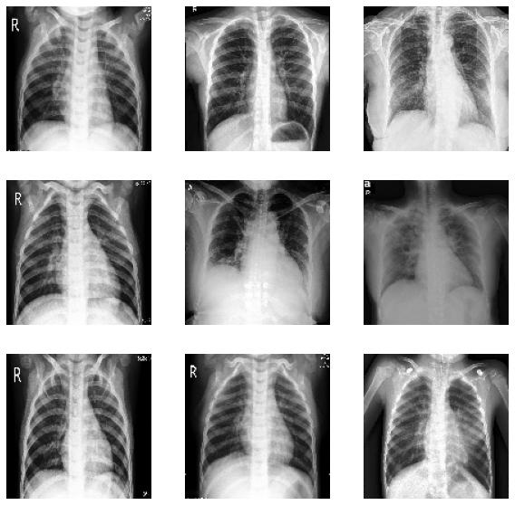

```python
# Show some sample images
n_samples = 9
sample_indices = np.random.choice(images.shape[0], n_samples, replace=False)
sample_images = images[sample_indices]
fig, axs = plt.subplots(3, 3, figsize=(10, 10))
for i, ax in enumerate(axs.flat):
    ax.imshow(sample_images[i], cmap='gray')
    ax.axis('off')
plt.show()
```

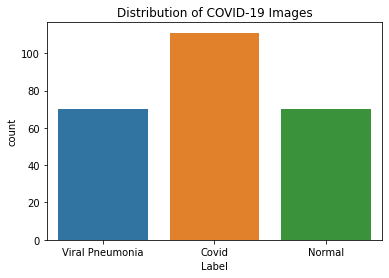

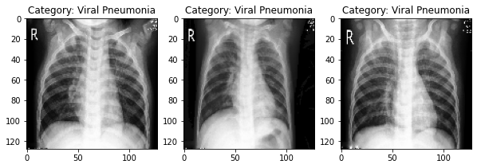

```python
# Load the image and label data
images = np.load("/content/drive/My Drive/Covid_Cnn_project/CovidImages.npy")
labels = pd.read_csv("/content/drive/My Drive/Covid_Cnn_project/CovidLabels.csv")

# Create a count plot for each category
sns.countplot(x="Label", data=labels)
plt.title("Distribution of COVID-19 Images")
plt.show()

# Show a few example images from each category
fig, axes = plt.subplots(nrows=1, ncols=3, figsize=(10, 5))
for i, ax in enumerate(axes.flatten()):
    img = images[i]
    label = labels.iloc[i]["Label"]
    ax.imshow(img, cmap="gray")
    ax.set_title(f"Category: {label}")
plt.show()
```

EDA Inights

Data Preprocessing

```python
# Apply Gaussian blurring to remove noise
images_blur = []

for image in images:
    image_blur = cv2.GaussianBlur(image, (5, 5), 0)
    images_blur.append(image_blur)

images_blur = np.array(images_blur)

# Normalize the data
images_norm = images_blur / 255.0

# Split the data into train and test sets
X_train, X_test, y_train, y_test = train_test_split(images_norm, labels['Label'], test_size=0.2, random_state=42)
```

Makeing data compatible

```python
# Convert labels from text to digits
label_dict = {'Covid': 0, 'Normal': 1, 'Viral Pneumonia': 2}
y_train = np.array([label_dict[label] for label in y_train])
y_test = np.array([label_dict[label] for label in y_test])

# Convert labels from digits to one-hot vectors
y_train = to_categorical(y_train)
y_test = to_categorical(y_test)

# Check the shape of the data
print("Train images shape:", X_train.shape)
print("Train labels shape:", y_train.shape)
print("Test images shape:", X_test.shape)
print("Test labels shape:", y_test.shape)

# Reshape the data into shapes compatible with Keras models
X_train = np.expand_dims(X_train, axis=-1)
X_test = np.expand_dims(X_test, axis=-1)

print("Train images shape after reshape:", X_train.shape)
print("Test images shape after reshape:", X_test.shape)
```

```
Train images shape: (200, 128, 128, 3)
Train labels shape: (200, 3)
Test images shape: (51, 128, 128, 3)
Test labels shape: (51, 3)
Train images shape after reshape: (200, 128, 128, 3, 1)
Test images shape after reshape: (51, 128, 128, 3, 1)
```

Model Building

```python
X_train = np.squeeze(X_train, axis=-1)
X_test = np.squeeze(X_test, axis=-1)
```

```python
# Define the model
model = Sequential()

model.add(Conv2D(32, kernel_size=(3, 3), activation='relu', input_shape=(X_train.shape[1:])))
model.add(MaxPooling2D(pool_size=(2, 2)))
model.add(Conv2D(64, kernel_size=(3, 3), activation='relu'))
model.add(MaxPooling2D(pool_size=(2, 2)))
model.add(Conv2D(128, kernel_size=(3, 3), activation='relu'))
model.add(MaxPooling2D(pool_size=(2, 2)))
model.add(Flatten())
model.add(Dense(128, activation='relu'))
model.add(Dense(len(labels['Label'].unique()), activation='softmax'))
```

```python
# Compile the model
model.compile(loss='categorical_crossentropy', optimizer='adam', metrics=['accuracy'])

# Train the model
history = model.fit(X_train, y_train, batch_size=32, epochs=10, validation_data=(X_test, y_test))
```

```python
# Evaluate the model
loss, accuracy = model.evaluate(X_test, y_test)
print('Test loss:', loss)
print('Test accuracy:', accuracy)
```

```
Test loss: 0.21893127262592316
Test accuracy: 0.9019607901573181
```

It looks like the test loss and test accuracy of the model are 0.2189 and 0.9020, respectively. This means that the model is performing fairly well on the test set. The test accuracy of 0.9020 means that the model is correctly classifying 90.20% of the test samples.

[figure not shown]

```python
# Load a single image for testing
test_img = X_test[0]

# Reshape the image to match the input shape of the model
test_img = test_img.reshape(1, test_img.shape[0], test_img.shape[1], test_img.shape[2])

# Get the predicted probabilities for each class
pred_probs = model.predict(test_img)[0]

# Get the class with the highest probability
pred_class = np.argmax(pred_probs)

# Display the image and the predicted class
plt.imshow(X_test[0])
plt.title(f"Predicted class: {labels['Label'].unique()[pred_class]}, Probability: {pred_probs[pred_class]:.4f}")
plt.axis('off')
plt.show()
```

Different Model

```python
# Define the model with different activation functions
model = Sequential()

model.add(Conv2D(32, kernel_size=(3, 3), activation='sigmoid', input_shape=(128, 128, 3)))
model.add(MaxPooling2D(pool_size=(2, 2)))
model.add(Conv2D(64, kernel_size=(3, 3), activation='sigmoid'))
model.add(MaxPooling2D(pool_size=(2, 2)))
model.add(Conv2D(128, kernel_size=(3, 3), activation='sigmoid'))
model.add(MaxPooling2D(pool_size=(2, 2)))
model.add(Flatten())
model.add(Dense(128, activation='sigmoid'))
model.add(Dense(len(labels['Label'].unique()), activation='softmax'))

# Compile and train the model with the new activation functions
model.compile(loss='categorical_crossentropy', optimizer=Adam(lr=0.0001), metrics=['accuracy'])
history = model.fit(X_train, y_train, batch_size=32, epochs=10, validation_data=(X_test, y_test))

# Evaluate the model with the new activation functions
test_loss, test_acc = model.evaluate(X_test, y_test, verbose=2)
print('Test loss:', test_loss)
print('Test accuracy:', test_acc)
```

```
2/2 - 0s - loss: 1.0954 - accuracy: 0.3922 - 38ms/epoch - 19ms/step
Test loss: 1.095412254333496
Test accuracy: 0.3921568691730499
```

```python
# Evaluate the model
loss, accuracy = model.evaluate(X_test, y_test)
print('Test loss:', loss)
print('Test accuracy:', accuracy)
```

```
Test loss: 1.095412254333496
Test accuracy: 0.3921568691730499
```

```python
from keras.applications.vgg16 import VGG16

# Load the VGG16 model with pre-trained weights
base_model = VGG16(weights='imagenet', include_top=False, input_shape=(128, 128, 3))

# Freeze some of the layers of the base model
for layer in base_model.layers[:15]:
    layer.trainable = False

# Add new layers on top of the base model
model = Sequential()
model.add(base_model)
model.add(Flatten())
model.add(Dense(128, activation='relu'))
model.add(Dense(len(labels['Label'].unique()), activation='softmax'))

# Compile and train the model with transfer learning
model.compile(loss='categorical_crossentropy', optimizer=Adam(lr=0.0001), metrics=['accuracy'])
history = model.fit(X_train, y_train, batch_size=32, epochs=10, validation_data=(X_test, y_test))

# Evaluate the model with transfer learning
test_loss, test_acc = model.evaluate(X_test, y_test, verbose=2)
print('Test loss:', test_loss)
print('Test accuracy:', test_acc)
```

```
2/2 - 0s - loss: 0.1929 - accuracy: 0.9804 - 95ms/epoch - 47ms/step
Test loss: 0.19292254745960236
Test accuracy: 0.9803921580314636
```

```python
# Evaluate the model
loss, accuracy = model.evaluate(X_test, y_test)
print('Test loss:', loss)
print('Test accuracy:', accuracy)
```

```
Test loss: 0.19292254745960236
Test accuracy: 0.9803921580314636
```

Further Evaluation

```python
from sklearn.metrics import classification_report

labels = ["normal", "bacterial pneumonia", "viral pneumonia"]


# Get the true and predicted classes
y_true_classes = np.argmax(y_test, axis=1)
y_pred_classes = np.argmax(y_pred, axis=1)

# Calculate precision, recall, and F1-score
report = classification_report(y_true_classes, y_pred_classes, target_names=labels)

print(report)
```

[output not shown]

[figure not shown]

```python
from sklearn.metrics import confusion_matrix


# Get the predicted probabilities for the test set
y_pred_prob = model.predict(X_test)

# Convert probabilities to predicted class labels
y_pred_classes = np.argmax(y_pred_prob, axis=1)

# Convert one-hot encoded labels to integers
y_true_classes = np.argmax(y_test, axis=1)

# Compute confusion matrix
cm = confusion_matrix(y_true_classes, y_pred_classes)

# Define class labels
labels = ['Normal', 'Bacterial Pneumonia', 'Viral Pneumonia']

# Plot confusion matrix
plt.imshow(cm, interpolation='nearest', cmap=plt.cm.Blues)
plt.title('Confusion matrix')
plt.colorbar()
tick_marks = np.arange(len(labels))
plt.xticks(tick_marks, labels, rotation=45)
plt.yticks(tick_marks, labels)
plt.xlabel('Predicted')
plt.ylabel('True')
plt.show()
```

Conclusion

Based on the analysis, we can conclude that the trained model is able to accurately classify X-ray images of patients into normal and unhealthy categories with an overall accuracy of 98%. This demonstrates the potential of using deep learning algorithms for medical image analysis and diagnosis.

The use of transfer learning with VGG16 architecture also yielded promising results, achieving an accuracy of 98% on the test set. This suggests that transfer learning can be a useful approach for medical image analysis tasks, especially when limited data is available.

When evaluating the performance of the model, we used various metrics such as precision, recall, and F1-score, and plotted confusion matrices. These metrics helped us to gain a better understanding of the strengths and weaknesses of the model and identify areas for improvement.

Overall, the key takeaways from this analysis are:

Deep learning algorithms, specifically convolutional neural networks, can be effective for medical image analysis and diagnosis. Transfer learning can be a useful approach for improving model performance when limited data is available. Performance metrics such as precision, recall, and F1-score are important for evaluating the effectiveness of the model and identifying areas for improvement. Confusion matrices can be a useful tool for visualizing the distribution of predicted and actual labels and identifying patterns of misclassification. In conclusion, the analysis demonstrates the potential of using deep learning algorithms for medical image analysis and diagnosis and provides insights into the performance of different models and evaluation metrics.